# Simple Trees: Classification

## Classification Trees

```r
library(tree)
```

Using Carseats in ISLR library:

```r
library(ISLR)
head(Carseats)
```

|  | Sales | CompPrice | Income | Advertising | Population | Price | ShelveLoc | Age | Education | Urban | US |
| --- | --- | --- | --- | --- | --- | --- | --- | --- | --- | --- | --- |
| 1 | 9.50 | 138 | 73 | 11 | 276 | 120 | Bad | 42 | 17 | Yes | Yes |
| 2 | 11.22 | 111 | 48 | 16 | 260 | 83 | Good | 65 | 10 | Yes | Yes |
| 3 | 10.06 | 113 | 35 | 10 | 269 | 80 | Medium | 59 | 12 | Yes | Yes |
| 4 | 7.40 | 117 | 100 | 4 | 466 | 97 | Medium | 55 | 14 | Yes | Yes |
| 5 | 4.15 | 141 | 64 | 3 | 340 | 128 | Bad | 38 | 13 | Yes | No |
| 6 | 10.81 | 124 | 113 | 13 | 501 | 72 | Bad | 78 | 16 | No | Yes |

```r
summary(Carseats)
```

```
     Sales          CompPrice       Income        Advertising       Population        Price        ShelveLoc
 Min.   : 0.000   Min.   : 77   Min.   : 21.00   Min.   : 0.000   Min.   : 10.0   Min.   : 24.0   Bad   : 96
 1st Qu.: 5.390   1st Qu.:115   1st Qu.: 42.75   1st Qu.: 0.000   1st Qu.:139.0   1st Qu.:100.0   Good  : 85
 Median : 7.490   Median :125   Median : 69.00   Median : 5.000   Median :272.0   Median :117.0   Medium:219
 Mean   : 7.496   Mean   :125   Mean   : 68.66   Mean   : 6.635   Mean   :264.8   Mean   :115.8
 3rd Qu.: 9.320   3rd Qu.:135   3rd Qu.: 91.00   3rd Qu.:12.000   3rd Qu.:398.5   3rd Qu.:131.0
 Max.   :16.270   Max.   :175   Max.   :120.00   Max.   :29.000   Max.   :509.0   Max.   :191.0
      Age          Education    Urban       US
 Min.   :25.00   Min.   :10.0   No :118   No :142
 1st Qu.:39.75   1st Qu.:12.0   Yes:282   Yes:258
 Median :54.50   Median :14.0
 Mean   :53.32   Mean   :13.9
 3rd Qu.:66.00   3rd Qu.:16.0
 Max.   :80.00   Max.   :18.0
```

We will use sales as response variable but we have to convert it to factor/categorical variable using if else.

```r
High <- ifelse(Carseats$Sales>8, 'YES', 'NO')
Carseats <- data.frame(Carseats, High)
head(Carseats)
```

|  | Sales | CompPrice | Income | Advertising | Population | Price | ShelveLoc | Age | Education | Urban | US | High |
| --- | --- | --- | --- | --- | --- | --- | --- | --- | --- | --- | --- | --- |
| 1 | 9.50 | 138 | 73 | 11 | 276 | 120 | Bad | 42 | 17 | Yes | Yes | YES |
| 2 | 11.22 | 111 | 48 | 16 | 260 | 83 | Good | 65 | 10 | Yes | Yes | YES |
| 3 | 10.06 | 113 | 35 | 10 | 269 | 80 | Medium | 59 | 12 | Yes | Yes | YES |
| 4 | 7.40 | 117 | 100 | 4 | 466 | 97 | Medium | 55 | 14 | Yes | Yes | NO |
| 5 | 4.15 | 141 | 64 | 3 | 340 | 128 | Bad | 38 | 13 | Yes | No | NO |
| 6 | 10.81 | 124 | 113 | 13 | 501 | 72 | Bad | 78 | 16 | No | Yes | YES |

The syntax of tree is similar to lm.

```r
tree.fit <- tree(High~.-Sales, Carseats)
summary(tree.fit)
```

```
Classification tree:
tree(formula = High ~ . - Sales, data = Carseats)
Variables actually used in tree construction:
[1] "ShelveLoc"   "Price"       "Income"      "CompPrice"   "Population"  "Advertising" "Age"
[8] "US"
Number of terminal nodes:  27
Residual mean deviance:  0.4575 = 170.7 / 373
Misclassification error rate: 0.09 = 36 / 400
```

Here, training error is 9%. The residual mean deviance is no of observations - no of terminal nodes. Trees can be graphically displayed using plot.

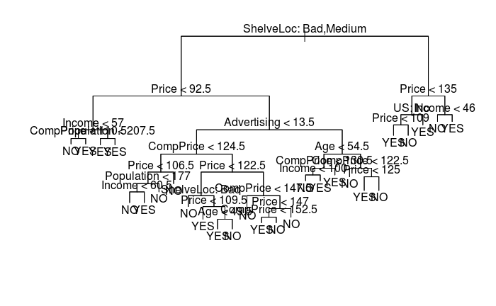

```r
plot(tree.fit)
text(tree.fit, pretty = 0)
```

Using the name of fit tree, we can get output corresponding to each branch of the tree.

```r
tree.fit
```

```
node), split, n, deviance, yval, (yprob)
      * denotes terminal node

  1) root 400 541.500 NO ( 0.59000 0.41000 )
    2) ShelveLoc: Bad,Medium 315 390.600 NO ( 0.68889 0.31111 )
      4) Price < 92.5 46  56.530 YES ( 0.30435 0.69565 )
        8) Income < 57 10  12.220 NO ( 0.70000 0.30000 )
         16) CompPrice < 110.5 5   0.000 NO ( 1.00000 0.00000 ) *
         17) CompPrice > 110.5 5   6.730 YES ( 0.40000 0.60000 ) *
        9) Income > 57 36  35.470 YES ( 0.19444 0.80556 )
         18) Population < 207.5 16  21.170 YES ( 0.37500 0.62500 ) *
         19) Population > 207.5 20   7.941 YES ( 0.05000 0.95000 ) *
      5) Price > 92.5 269 299.800 NO ( 0.75465 0.24535 )
       10) Advertising < 13.5 224 213.200 NO ( 0.81696 0.18304 )
         20) CompPrice < 124.5 96  44.890 NO ( 0.93750 0.06250 )
           40) Price < 106.5 38  33.150 NO ( 0.84211 0.15789 )
             80) Population < 177 12  16.300 NO ( 0.58333 0.41667 )
              160) Income < 60.5 6   0.000 NO ( 1.00000 0.00000 ) *
              161) Income > 60.5 6   5.407 YES ( 0.16667 0.83333 ) *
             81) Population > 177 26   8.477 NO ( 0.96154 0.03846 ) *
           41) Price > 106.5 58   0.000 NO ( 1.00000 0.00000 ) *
         21) CompPrice > 124.5 128 150.200 NO ( 0.72656 0.27344 )
           42) Price < 122.5 51  70.680 YES ( 0.49020 0.50980 )
             84) ShelveLoc: Bad 11   6.702 NO ( 0.90909 0.09091 ) *
             85) ShelveLoc: Medium 40  52.930 YES ( 0.37500 0.62500 )
              170) Price < 109.5 16   7.481 YES ( 0.06250 0.93750 ) *
              171) Price > 109.5 24  32.600 NO ( 0.58333 0.41667 )
                342) Age < 49.5 13  16.050 YES ( 0.30769 0.69231 ) *
                343) Age > 49.5 11   6.702 NO ( 0.90909 0.09091 ) *
           43) Price > 122.5 77  55.540 NO ( 0.88312 0.11688 )
             86) CompPrice < 147.5 58  17.400 NO ( 0.96552 0.03448 ) *
             87) CompPrice > 147.5 19  25.010 NO ( 0.63158 0.36842 )
              174) Price < 147 12  16.300 YES ( 0.41667 0.58333 )
                348) CompPrice < 152.5 7   5.742 YES ( 0.14286 0.85714 ) *
                349) CompPrice > 152.5 5   5.004 NO ( 0.80000 0.20000 ) *
              175) Price > 147 7   0.000 NO ( 1.00000 0.00000 ) *
       11) Advertising > 13.5 45  61.830 YES ( 0.44444 0.55556 )
         22) Age < 54.5 25  25.020 YES ( 0.20000 0.80000 )
           44) CompPrice < 130.5 14  18.250 YES ( 0.35714 0.64286 )
             88) Income < 100 9  12.370 NO ( 0.55556 0.44444 ) *
             89) Income > 100 5   0.000 YES ( 0.00000 1.00000 ) *
           45) CompPrice > 130.5 11   0.000 YES ( 0.00000 1.00000 ) *
         23) Age > 54.5 20  22.490 NO ( 0.75000 0.25000 )
           46) CompPrice < 122.5 10   0.000 NO ( 1.00000 0.00000 ) *
           47) CompPrice > 122.5 10  13.860 NO ( 0.50000 0.50000 )
             94) Price < 125 5   0.000 YES ( 0.00000 1.00000 ) *
             95) Price > 125 5   0.000 NO ( 1.00000 0.00000 ) *
    3) ShelveLoc: Good 85  90.330 YES ( 0.22353 0.77647 )
      6) Price < 135 68  49.260 YES ( 0.11765 0.88235 )
       12) US: No 17  22.070 YES ( 0.35294 0.64706 )
         24) Price < 109 8   0.000 YES ( 0.00000 1.00000 ) *
         25) Price > 109 9  11.460 NO ( 0.66667 0.33333 ) *
       13) US: Yes 51  16.880 YES ( 0.03922 0.96078 ) *
      7) Price > 135 17  22.070 NO ( 0.64706 0.35294 )
       14) Income < 46 6   0.000 NO ( 1.00000 0.00000 ) *
       15) Income > 46 11  15.160 YES ( 0.45455 0.54545 ) *
```

To evaluate the performance of the tree, we must compute and judge on the basis of test error instead of training error. Therefore, we divide the data into training and test data. We will use predict to make predictions on test with type =“class” for classification.

```r
set.seed(2)
train <- sample(1:nrow(Carseats), 200)
Carseats.test <- Carseats[-train,]
High.test <- High[-train]
tree.fit <- tree(High~.-Sales, Carseats, subset = train)
summary(tree.fit)
```

```
Classification tree:
tree(formula = High ~ . - Sales, data = Carseats, subset = train)
Variables actually used in tree construction:
[1] "ShelveLoc"   "Price"       "Income"      "Age"         "Advertising" "CompPrice"   "Population"
Number of terminal nodes:  19
Residual mean deviance:  0.4282 = 77.51 / 181
Misclassification error rate: 0.105 = 21 / 200
```

```r
tree.predict <- predict(tree.fit, Carseats.test, type = "class")
table.pred <- table(tree.predict, High.test)
table.pred
```

```
            High.test
tree.predict NO YES
         NO  86  27
         YES 30  57
```

```r
acc <- table.pred['NO','NO']+table.pred['YES','YES']
acc/200
```

```
[1] 0.715
```

It gives accuracy of 71.5%. Now we will see if cross validation finds out a tree with a complexity that gives improved results as compared to results above. We will use classification error as a guidance to select the best tree by using FUN = prune.misclass.

```r
set.seed(3)
cv.tree.carseats <- cv.tree(tree.fit, FUN = prune.misclass)
names(cv.tree.carseats)
```

```
[1] "size"   "dev"    "k"      "method"
```

cv.tree gives the size of each tree and corresponding error rate and corresponding k(cost complexity parameter used) which is alpha.

```r
cv.tree.carseats
```

```
$size
[1] 19 17 14 13  9  7  3  2  1

$dev
[1] 55 55 53 52 50 56 69 65 80

$k
[1]       -Inf  0.0000000  0.6666667  1.0000000  1.7500000  2.0000000  4.2500000  5.0000000 23.0000000

$method
[1] "misclass"

attr(,"class")
[1] "prune"         "tree.sequence"
```

Dev corresponds to cross validation error in this case. It says that a tree with 9 terminal nodes and error of 50 is best tree so predicting test values on this.

We now apply prune.misclass() in order to prune the to obtain nine node tree.

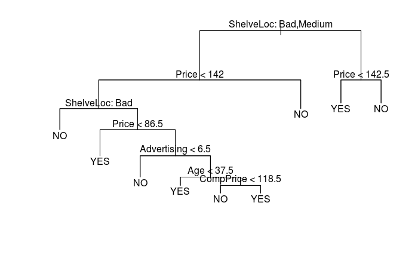

```r
prune.tree <-prune.misclass(tree.fit, best = 9)
plot(prune.tree)
text(prune.tree, pretty=0)
```

Making predictions on test data.

```r
tree.pred <- predict(prune.tree, Carseats.test, type = "class")
prune.table <- table(tree.pred, High.test)
```

Accuracy is:

```r
(prune.table['NO','NO']+prune.table['YES','YES'])/200
```

```
[1] 0.77
```

If we increase the number of terminal nodes ie value of best. We will get a tree with lower accuracy.

```r
prune.tree <-prune.misclass(tree.fit, best = 15)
tree.pred <- predict(prune.tree, Carseats.test, type = "class")
prune.table <- table(tree.pred, High.test)
(prune.table['NO','NO']+prune.table['YES','YES'])/200
```

```
[1] 0.74
```